# DSassignment_ggplot

Judy Ban

February 15, 2018

# load packages

```r
library(tidyverse)
library(phyloseq)
```

# load Saanich.metadata.txt

```r
metadata = read.table (file="Saanich.metadata.txt", header=TRUE, row.names=1, sep="\t", na.strings=c("NAN","NA","."))
```

# Exercise 1

plot the points with NO2_uM values on the x-axis and Depth_m values on the y-axis

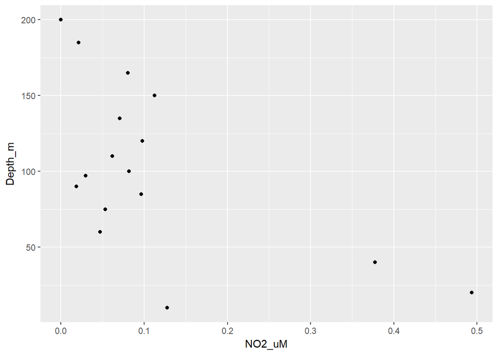

```r
ggplot(metadata, aes(x=NO2_uM, y=Depth_m)) +
  geom_point()
```

Change points into purple and triangles

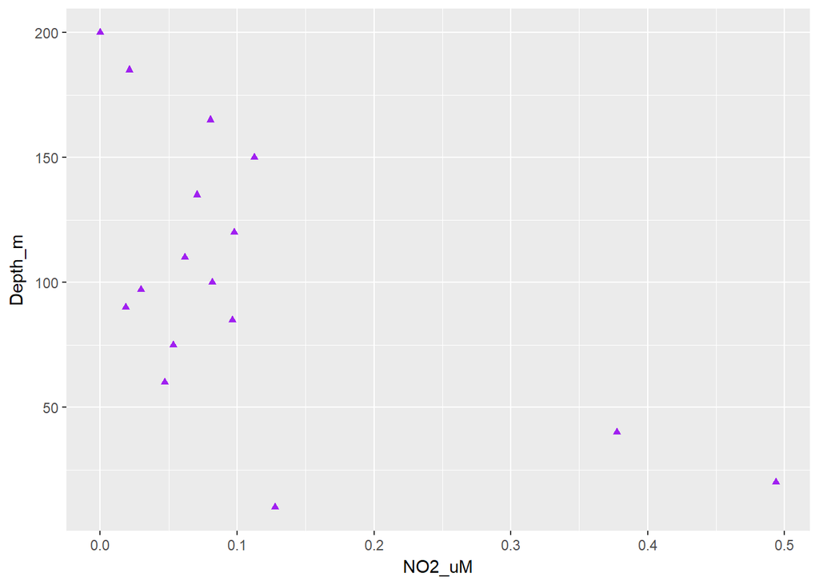

```r
ggplot(metadata, aes(x=NO2_uM, y=Depth_m)) +
  geom_point(color="purple", pch=17)
```

# Exercise 2

changing temperature from celsius to fehrenheit, then plotting the temperature in F on the x axis and Depth_m on the Y axis

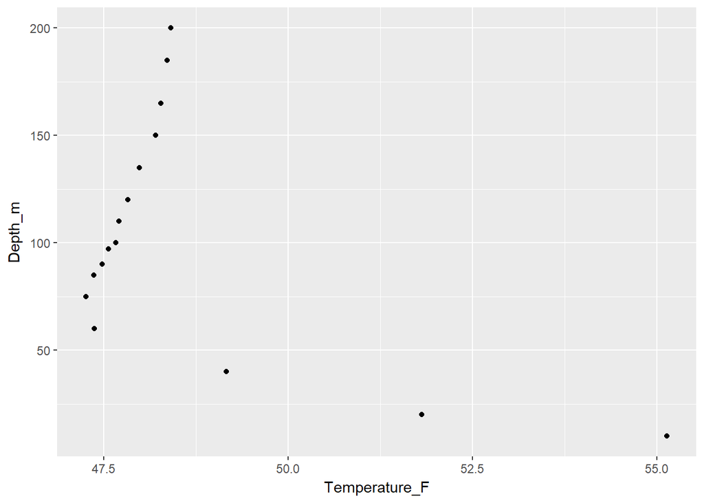

```r
metadata %>%
  mutate(Temperature_F = Temperature_C*1.8+32) %>%
  ggplot(aes(x=Temperature_F, y=Depth_m)) +
  geom_point()
```

# Exercise 3

load physeq

```r
load("phyloseq_object.RData")
```

physeq

Transform absolute abundance into percent abundance

```r
physeq_percent = transform_sample_counts(physeq, function(x) 100 * x/sum(x))
```

Plotting the genus level communities by depth with respect to percent abundance

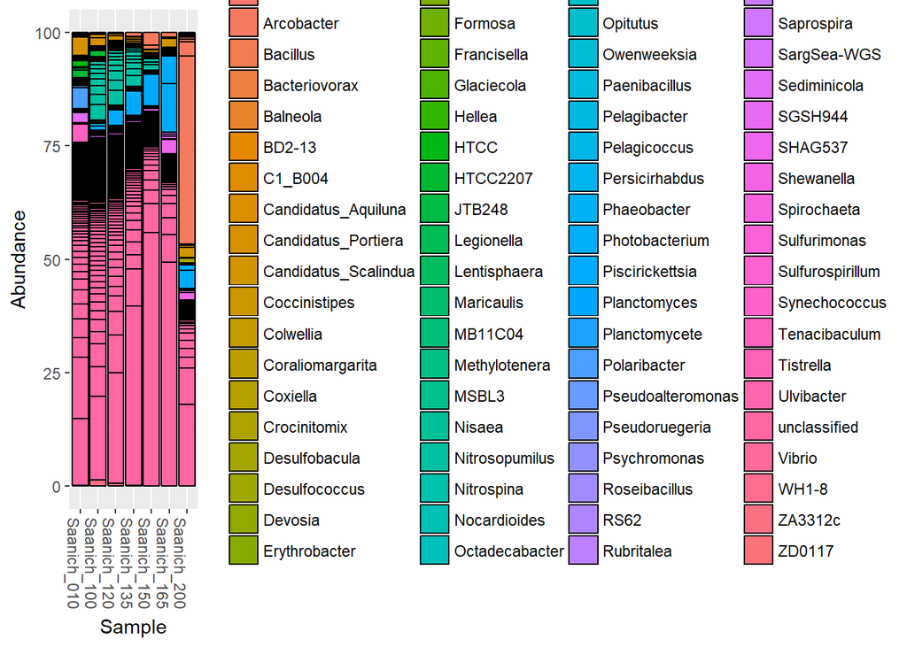

```r
plot_bar(physeq_percent, fill="Genus")
```

Removing the black lines on the bars, and making the lables of the axis as well as the title more descriptive

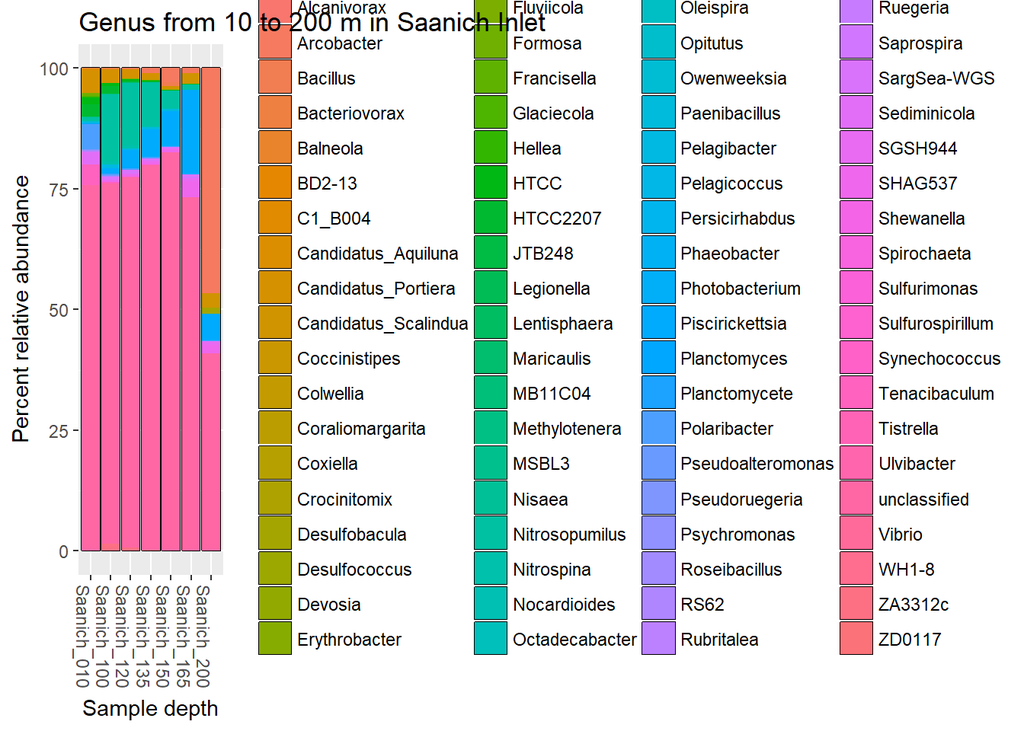

```r
plot_bar(physeq_percent, fill="Genus") +
  geom_bar(aes(fill=Genus), stat="identity") + labs( x = "Sample depth", y = "Percent relative abundance",
                                                       title ="Genus from 10 to 200 m in Saanich Inlet")
```

# Exercise 4

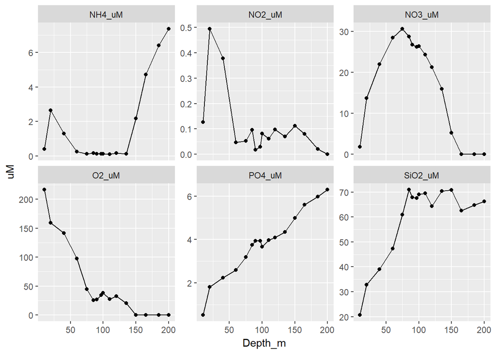

```r
metadata %>%
  gather(nutrients, uM, NH4_uM,NO2_uM,NO3_uM,O2_uM,PO4_uM,SiO2_uM) %>%
  ggplot(fill="nutrients") +
  geom_line(aes(x=Depth_m, y=uM), stat="identity") +
  geom_point(aes(x=Depth_m, y=uM), stat="identity") +
  facet_wrap(~nutrients, scales="free_y") +
  theme(legend.position="none")
```